# How does the weather affect Capital Bikeshare hire?

Replication code for the bike-sharing regression exercise

11 November 2026

```r
library(tidyverse)   # readr, dplyr, ggplot2, tidyr, purrr
library(broom)       # tidy() / glance() for model output
library(knitr)       # kable() for tables

theme_set(theme_minimal(base_size = 12))
```

# 1 Data

`day.csv` is the daily file from the UCI Machine Learning Repository *Bike Sharing Dataset* (Fanaee-T & Gama, 2013). It has one row per day from 1 January 2011 to 31 December 2012. Put `day.csv` in the same folder as this `.Rmd` before knitting.

```r
bikes_raw <- read_csv("day.csv", show_col_types = FALSE)
bikes_raw
```

```
## # A tibble: 731 × 16
##    instant dteday     season    yr  mnth holiday weekday workingday weathersit
##      <dbl> <date>      <dbl> <dbl> <dbl>   <dbl>   <dbl>      <dbl>      <dbl>
##  1       1 2011-01-01      1     0     1       0       6          0          2
##  2       2 2011-01-02      1     0     1       0       0          0          2
##  3       3 2011-01-03      1     0     1       0       1          1          1
##  4       4 2011-01-04      1     0     1       0       2          1          1
##  5       5 2011-01-05      1     0     1       0       3          1          1
##  6       6 2011-01-06      1     0     1       0       4          1          1
##  7       7 2011-01-07      1     0     1       0       5          1          2
##  8       8 2011-01-08      1     0     1       0       6          0          2
##  9       9 2011-01-09      1     0     1       0       0          0          1
## 10      10 2011-01-10      1     0     1       0       1          1          1
## # ℹ 721 more rows
## # ℹ 7 more variables: temp <dbl>, atemp <dbl>, hum <dbl>, windspeed <dbl>,
## #   casual <dbl>, registered <dbl>, cnt <dbl>
```

## 1.1 Data dictionary

```r
data_dictionary <- tribble(
  ~variable,    ~description,
  "instant",    "Record index",
  "dteday",     "Date",
  "season",     "Season (1 = spring, 2 = summer, 3 = fall, 4 = winter)",
  "yr",         "Year (0 = 2011, 1 = 2012)",
  "mnth",       "Month (1 to 12)",
  "holiday",    "1 if the day is a public holiday, 0 otherwise",
  "weekday",    "Day of the week (0 = Sunday to 6 = Saturday)",
  "workingday", "1 if the day is neither a weekend nor a holiday, 0 otherwise",
  "weathersit", "Weather (1 = clear/partly cloudy; 2 = mist/cloudy; 3 = light snow or rain; 4 = heavy rain, ice, snow or fog)",
  "temp",       "Normalised temperature: (t - t_min) / (t_max - t_min), t_min = -8, t_max = +39 degrees C",
  "atemp",      "Normalised 'feels like' temperature: t_min = -16, t_max = +50 degrees C",
  "hum",        "Normalised humidity (divided by 100)",
  "windspeed",  "Normalised wind speed (divided by 67, the maximum)",
  "casual",     "Count of rentals by casual (unregistered) users",
  "registered", "Count of rentals by registered users",
  "cnt",        "Total count of rentals (casual + registered)",
  "temp_c",     "NEW: temperature in degrees C = temp * (39 - (-8)) + (-8)",
  "wind_mph",   "NEW: wind speed in miles per hour = windspeed * 67 (km/h) * 0.621371"
)

kable(data_dictionary, col.names = c("Variable", "Description"))
```

| Variable | Description |
| --- | --- |
| instant | Record index |
| dteday | Date |
| season | Season (1 = spring, 2 = summer, 3 = fall, 4 = winter) |
| yr | Year (0 = 2011, 1 = 2012) |
| mnth | Month (1 to 12) |
| holiday | 1 if the day is a public holiday, 0 otherwise |
| weekday | Day of the week (0 = Sunday to 6 = Saturday) |
| workingday | 1 if the day is neither a weekend nor a holiday, 0 otherwise |
| weathersit | Weather (1 = clear/partly cloudy; 2 = mist/cloudy; 3 = light snow or rain; 4 = heavy rain, ice, snow or fog) |
| temp | Normalised temperature: (t - t_min) / (t_max - t_min), t_min = -8, t_max = +39 degrees C |
| atemp | Normalised ‘feels like’ temperature: t_min = -16, t_max = +50 degrees C |
| hum | Normalised humidity (divided by 100) |
| windspeed | Normalised wind speed (divided by 67, the maximum) |
| casual | Count of rentals by casual (unregistered) users |
| registered | Count of rentals by registered users |
| cnt | Total count of rentals (casual + registered) |
| temp_c | NEW: temperature in degrees C = temp * (39 - (-8)) + (-8) |
| wind_mph | NEW: wind speed in miles per hour = windspeed * 67 (km/h) * 0.621371 |

## 1.2 Un-normalising temperature and wind speed

Temperature was normalised as $(t - t_{min}) / (t_{max} - t_{min})$ with $t_{min} = -8$ and $t_{max} = 39$, so $t = \text{temp} \times 47 - 8$. Wind speed was divided by its maximum of 67. The source weather data (freemeteo) report wind in km/h, so we multiply by 67 to get km/h and then by 0.621371 to get miles per hour.

```r
km_to_miles <- 0.621371

bikes <- bikes_raw |>
  mutate(
    date     = as.Date(dteday),
    temp_c   = temp * (39 - (-8)) + (-8),
    wind_kmh = windspeed * 67,
    wind_mph = wind_kmh * km_to_miles,
    month    = factor(month.abb[mnth], levels = month.abb)
  )

bikes |>
  select(cnt, temp_c, wind_mph) |>
  summary()
```

```
##       cnt           temp_c          wind_mph
##  Min.   :  22   Min.   :-5.221   Min.   : 0.9322
##  1st Qu.:3152   1st Qu.: 7.843   1st Qu.: 5.6182
##  Median :4548   Median :15.422   Median : 7.5343
##  Mean   :4504   Mean   :15.283   Mean   : 7.9303
##  3rd Qu.:5956   3rd Qu.:22.805   3rd Qu.: 9.7092
##  Max.   :8714   Max.   :32.498   Max.   :21.1266
```

```r
descriptives <- bikes |>
  select(`Bikes rented (cnt)` = cnt,
         `Temperature (°C)` = temp_c,
         `Wind speed (mph)` = wind_mph) |>
  pivot_longer(everything(), names_to = "Variable") |>
  group_by(Variable) |>
  summarise(N = n(), Mean = mean(value), SD = sd(value),
            Min = min(value), Median = median(value), Max = max(value),
            .groups = "drop")

kable(descriptives, digits = 1, caption = "Table 1. Descriptive statistics (N = 731 days)")
```

Table 1. Descriptive statistics (N = 731 days)

| Variable | N | Mean | SD | Min | Median | Max |
| --- | --- | --- | --- | --- | --- | --- |
| Bikes rented (cnt) | 731 | 4504.3 | 1937.2 | 22.0 | 4548.0 | 8714.0 |
| Temperature (°C) | 731 | 15.3 | 8.6 | -5.2 | 15.4 | 32.5 |
| Wind speed (mph) | 731 | 7.9 | 3.2 | 0.9 | 7.5 | 21.1 |

# 2 Univariate plots

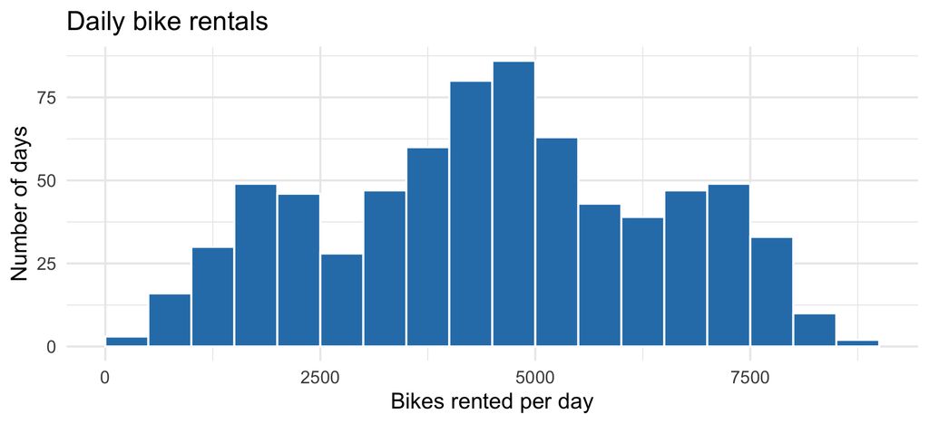

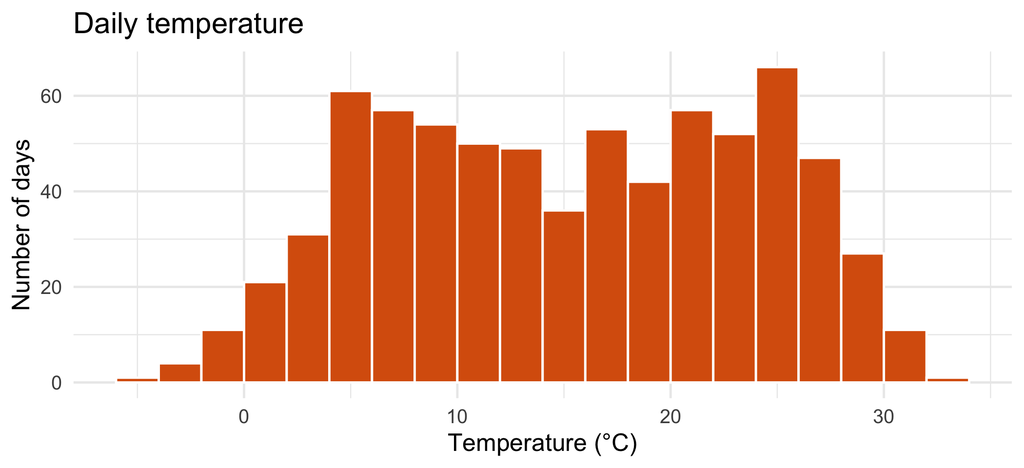

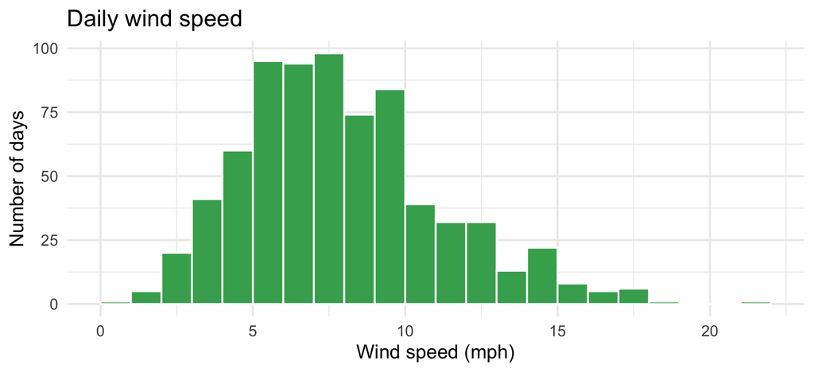

```r
p_cnt <- ggplot(bikes, aes(cnt)) +
  geom_histogram(binwidth = 500, boundary = 0, fill = "#2C7FB8", colour = "white") +
  labs(x = "Bikes rented per day", y = "Number of days",
       title = "Daily bike rentals")

p_temp <- ggplot(bikes, aes(temp_c)) +
  geom_histogram(binwidth = 2, boundary = 0, fill = "#D95F0E", colour = "white") +
  labs(x = "Temperature (°C)", y = "Number of days",
       title = "Daily temperature")

p_wind <- ggplot(bikes, aes(wind_mph)) +
  geom_histogram(binwidth = 1, boundary = 0, fill = "#41AB5D", colour = "white") +
  labs(x = "Wind speed (mph)", y = "Number of days",
       title = "Daily wind speed")

p_cnt; p_temp; p_wind
```

# 3 Bivariate plots

Always plot your data: a correlation or a slope can hide curvature, outliers or clusters.

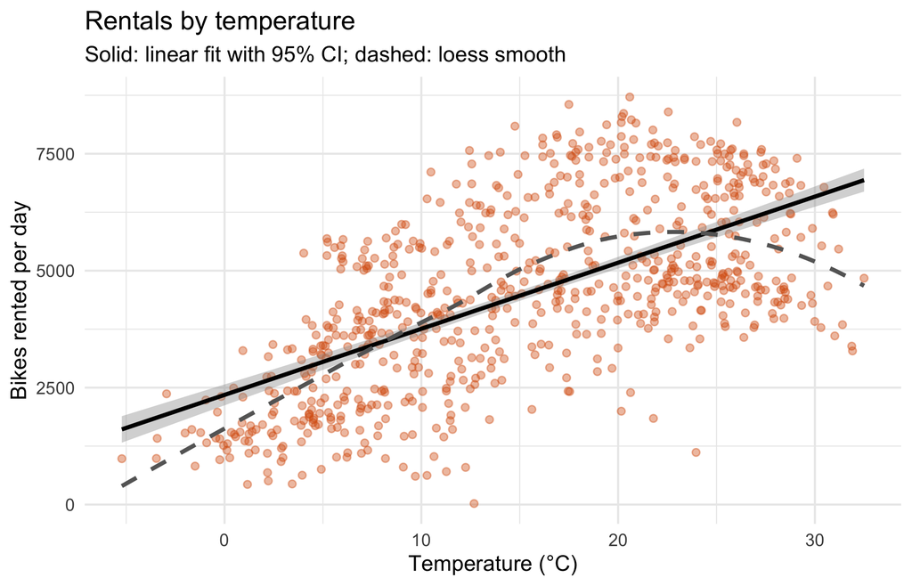

```r
ggplot(bikes, aes(temp_c, cnt)) +
  geom_point(alpha = 0.4, colour = "#D95F0E") +
  geom_smooth(method = "lm", formula = y ~ x, colour = "black") +
  geom_smooth(method = "loess", formula = y ~ x, se = FALSE,
              colour = "grey40", linetype = "dashed") +
  labs(x = "Temperature (°C)", y = "Bikes rented per day",
       title = "Rentals by temperature",
       subtitle = "Solid: linear fit with 95% CI; dashed: loess smooth")
```

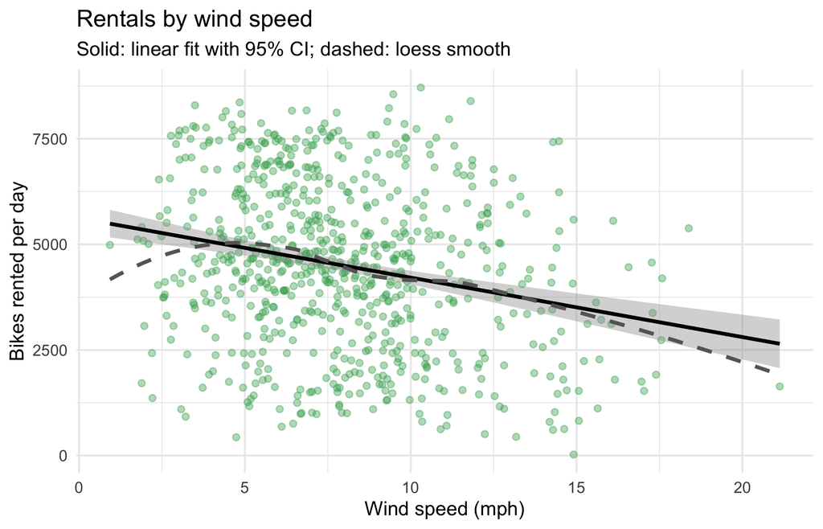

```r
ggplot(bikes, aes(wind_mph, cnt)) +
  geom_point(alpha = 0.4, colour = "#41AB5D") +
  geom_smooth(method = "lm", formula = y ~ x, colour = "black") +
  geom_smooth(method = "loess", formula = y ~ x, se = FALSE,
              colour = "grey40", linetype = "dashed") +
  labs(x = "Wind speed (mph)", y = "Bikes rented per day",
       title = "Rentals by wind speed",
       subtitle = "Solid: linear fit with 95% CI; dashed: loess smooth")
```

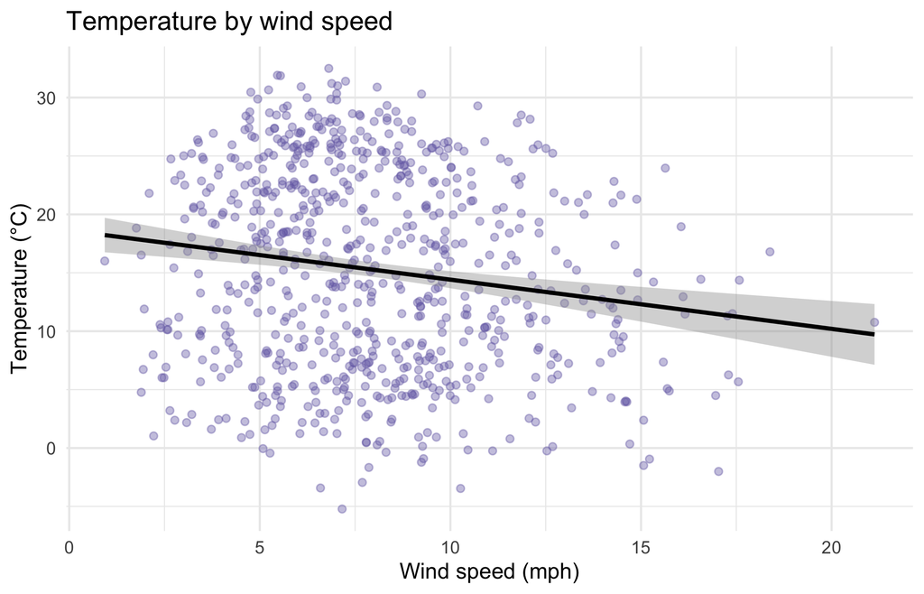

```r
ggplot(bikes, aes(wind_mph, temp_c)) +
  geom_point(alpha = 0.4, colour = "#756BB1") +
  geom_smooth(method = "lm", formula = y ~ x, colour = "black") +
  labs(x = "Wind speed (mph)", y = "Temperature (°C)",
       title = "Temperature by wind speed")
```

# 4 Correlations

```r
cor_matrix <- bikes |>
  select(`Bikes rented` = cnt, `Temperature (°C)` = temp_c, `Wind speed (mph)` = wind_mph) |>
  cor()

kable(cor_matrix, digits = 2, caption = "Table 2. Pearson correlations")
```

Table 2. Pearson correlations

|  | Bikes rented | Temperature (°C) | Wind speed (mph) |
| --- | --- | --- | --- |
| Bikes rented | 1.00 | 0.63 | -0.23 |
| Temperature (°C) | 0.63 | 1.00 | -0.16 |
| Wind speed (mph) | -0.23 | -0.16 | 1.00 |

```r
# Test of each pairwise correlation, with 95% CIs
cor_tests <- list(
  "Count – temperature"      = cor.test(bikes$cnt,    bikes$temp_c),
  "Count – wind speed"       = cor.test(bikes$cnt,    bikes$wind_mph),
  "Temperature – wind speed" = cor.test(bikes$temp_c, bikes$wind_mph)
) |>
  map_dfr(tidy, .id = "Pair") |>
  select(Pair, r = estimate, conf.low, conf.high, t = statistic, df = parameter, p.value)

kable(cor_tests, digits = 3)
```

| Pair | r | conf.low | conf.high | t | df | p.value |
| --- | --- | --- | --- | --- | --- | --- |
| Count – temperature | 0.627 | 0.581 | 0.670 | 21.759 | 729 | 0 |
| Count – wind speed | -0.235 | -0.302 | -0.165 | -6.514 | 729 | 0 |
| Temperature – wind speed | -0.158 | -0.228 | -0.086 | -4.319 | 729 | 0 |

A low correlation between the two predictors (wind speed and temperature) is good news: there is little **multicollinearity**, so the two variables carry largely separate information. Their coefficients in a multiple regression can therefore be estimated precisely (small standard errors, variance inflation factor close to 1) and are not very sensitive to which other predictor is in the model.

```r
r_tw <- cor(bikes$temp_c, bikes$wind_mph)
vif  <- 1 / (1 - r_tw^2)
vif
```

```
## [1] 1.025585
```

# 5 Regressions

```r
m_wind <- lm(cnt ~ wind_mph,          data = bikes)
m_temp <- lm(cnt ~ temp_c,            data = bikes)
m_both <- lm(cnt ~ wind_mph + temp_c, data = bikes)

models <- list("Model 1: wind" = m_wind,
               "Model 2: temperature" = m_temp,
               "Model 3: wind + temperature" = m_both)

coef_table <- models |>
  map_dfr(~ tidy(.x, conf.int = TRUE), .id = "Model") |>
  select(Model, term, estimate, std.error, conf.low, conf.high, statistic, p.value)

kable(coef_table, digits = c(0, 0, 1, 1, 1, 1, 2, 4),
      caption = "Table 3. Unstandardised regression coefficients with 95% CIs")
```

Table 3. Unstandardised regression coefficients with 95% CIs

| Model | term | estimate | std.error | conf.low | conf.high | statistic | p.value |
| --- | --- | --- | --- | --- | --- | --- | --- |
| Model 1: wind | (Intercept) | 5621.2 | 185.1 | 5257.8 | 5984.5 | 30.37 | 0 |
| Model 1: wind | wind_mph | -140.8 | 21.6 | -183.3 | -98.4 | -6.51 | 0 |
| Model 2: temperature | (Intercept) | 2345.0 | 113.9 | 2121.4 | 2568.5 | 20.59 | 0 |
| Model 2: temperature | temp_c | 141.3 | 6.5 | 128.5 | 154.0 | 21.76 | 0 |
| Model 3: wind + temperature | (Intercept) | 3081.9 | 189.4 | 2710.0 | 3453.7 | 16.27 | 0 |
| Model 3: wind + temperature | wind_mph | -83.4 | 17.3 | -117.3 | -49.5 | -4.83 | 0 |
| Model 3: wind + temperature | temp_c | 136.4 | 6.5 | 123.6 | 149.1 | 21.05 | 0 |

```r
fit_table <- models |>
  map_dfr(glance, .id = "Model") |>
  select(Model, r.squared, adj.r.squared, sigma, statistic, df, df.residual, p.value)

kable(fit_table, digits = 3, caption = "Table 4. Model fit")
```

Table 4. Model fit

| Model | r.squared | adj.r.squared | sigma | statistic | df | df.residual | p.value |
| --- | --- | --- | --- | --- | --- | --- | --- |
| Model 1: wind | 0.055 | 0.054 | 1884.465 | 42.438 | 1 | 729 | 0 |
| Model 2: temperature | 0.394 | 0.393 | 1509.388 | 473.472 | 1 | 729 | 0 |
| Model 3: wind + temperature | 0.413 | 0.411 | 1486.806 | 255.639 | 2 | 728 | 0 |

```r
b <- function(model, term) unname(coef(model)[term])

b_temp_uni  <- b(m_temp, "temp_c")
b_wind_uni  <- b(m_wind, "wind_mph")
b_temp_both <- b(m_both, "temp_c")
b_wind_both <- b(m_both, "wind_mph")

tibble(
  Question = c("Per °C (temperature alone)",
               "Per mph (wind alone)",
               "Per °C, holding wind constant",
               "Per mph, holding temperature constant"),
  `Change in bikes per day` = c(b_temp_uni, b_wind_uni, b_temp_both, b_wind_both)
) |>
  kable(digits = 1)
```

| Question | Change in bikes per day |
| --- | --- |
| Per °C (temperature alone) | 141.3 |
| Per mph (wind alone) | -140.8 |
| Per °C, holding wind constant | 136.4 |
| Per mph, holding temperature constant | -83.4 |

## 5.1 Why does the wind-speed estimate change between models?

In Model 1, wind speed is the only predictor, so its slope picks up anything correlated with wind that also affects rentals. Windier days in Washington DC tend to be cooler (negative correlation in Table 2), and cooler days have fewer rentals. Part of the apparent “wind effect” in Model 1 is therefore really a temperature effect: this is **omitted variable bias**. Model 3 estimates the association with wind *holding temperature constant*, removing the part shared with temperature. The size of the change is roughly the temperature slope multiplied by the slope of temperature on wind:

```r
# Omitted variable bias identity: b_wind_uni = b_wind_both + b_temp_both * delta,
# where delta is the slope from regressing temperature on wind speed
delta <- coef(lm(temp_c ~ wind_mph, data = bikes))["wind_mph"]

tibble(
  `Wind slope, Model 1`          = b_wind_uni,
  `Wind slope, Model 3`          = b_wind_both,
  `Temp slope (Model 3) × delta` = b_temp_both * delta,
  `Model 3 + bias term`          = b_wind_both + b_temp_both * delta
) |>
  kable(digits = 2)
```

| Wind slope, Model 1 | Wind slope, Model 3 | Temp slope (Model 3) × delta | Model 3 + bias term |
| --- | --- | --- | --- |
| -140.83 | -83.4 | -57.43 | -140.83 |

## 5.2 Which matters more: temperature or wind speed?

The raw coefficients are in different units (°C vs mph), so we compare them on a common scale: (a) standardised coefficients (change in SD of rentals per SD of the predictor), and (b) the variance in rentals explained by each variable on its own.

```r
bikes_z <- bikes |>
  mutate(across(c(cnt, temp_c, wind_mph), ~ as.numeric(scale(.x))))

m_both_z <- lm(cnt ~ wind_mph + temp_c, data = bikes_z)

tidy(m_both_z, conf.int = TRUE) |>
  filter(term != "(Intercept)") |>
  select(term, beta = estimate, conf.low, conf.high) |>
  kable(digits = 2, caption = "Table 5. Standardised coefficients from Model 3")
```

Table 5. Standardised coefficients from Model 3

| term | beta | conf.low | conf.high |
| --- | --- | --- | --- |
| wind_mph | -0.14 | -0.20 | -0.08 |
| temp_c | 0.61 | 0.55 | 0.66 |

```r
tibble(
  Model = c("Wind only", "Temperature only", "Both"),
  R2    = c(glance(m_wind)$r.squared, glance(m_temp)$r.squared, glance(m_both)$r.squared)
) |>
  kable(digits = 3)
```

| Model | R2 |
| --- | --- |
| Wind only | 0.055 |
| Temperature only | 0.394 |
| Both | 0.413 |

```r
# A 1 SD change in each predictor, in the original units, and the change in rentals it implies
tibble(
  Predictor = c("Temperature", "Wind speed"),
  `1 SD`    = c(sd(bikes$temp_c), sd(bikes$wind_mph)),
  `Change in bikes per 1 SD (Model 3)` = c(b_temp_both * sd(bikes$temp_c),
                                           b_wind_both * sd(bikes$wind_mph))
) |>
  kable(digits = 1)
```

| Predictor | 1 SD | Change in bikes per 1 SD (Model 3) |
| --- | --- | --- |
| Temperature | 8.6 | 1173.1 |
| Wind speed | 3.2 | -269.1 |

# 6 Does the temperature relationship vary across the year?

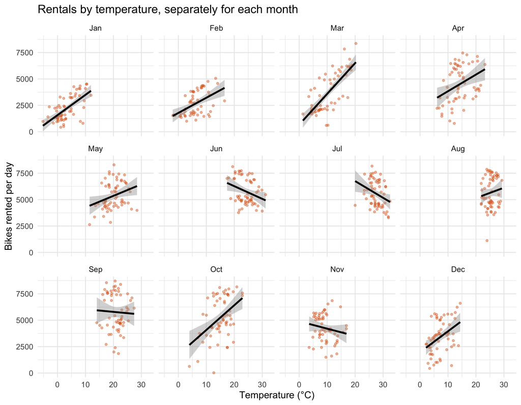

```r
ggplot(bikes, aes(temp_c, cnt)) +
  geom_point(alpha = 0.4, size = 1, colour = "#D95F0E") +
  geom_smooth(method = "lm", formula = y ~ x, colour = "black") +
  facet_wrap(~ month, ncol = 4) +
  labs(x = "Temperature (°C)", y = "Bikes rented per day",
       title = "Rentals by temperature, separately for each month")
```

```r
month_slopes <- bikes |>
  group_by(month) |>
  group_modify(~ tidy(lm(cnt ~ temp_c, data = .x), conf.int = TRUE)) |>
  ungroup() |>
  filter(term == "temp_c") |>
  select(month, estimate, std.error, conf.low, conf.high, p.value)

kable(month_slopes, digits = c(0, 1, 1, 1, 1, 4),
      caption = "Table 6. Slope of rentals on temperature (bikes per °C), by month")
```

Table 6. Slope of rentals on temperature (bikes per °C), by month

| month | estimate | std.error | conf.low | conf.high | p.value |
| --- | --- | --- | --- | --- | --- |
| Jan | 192.2 | 29.2 | 133.8 | 250.6 | 0.0000 |
| Feb | 143.7 | 33.8 | 75.9 | 211.5 | 0.0001 |
| Mar | 291.5 | 32.7 | 226.1 | 356.8 | 0.0000 |
| Apr | 157.6 | 53.0 | 51.6 | 263.6 | 0.0043 |
| May | 109.8 | 46.8 | 16.3 | 203.4 | 0.0222 |
| Jun | -120.0 | 50.0 | -220.1 | -19.9 | 0.0197 |
| Jul | -158.3 | 64.2 | -286.7 | -29.9 | 0.0165 |
| Aug | 97.9 | 102.1 | -106.3 | 302.0 | 0.3416 |
| Sep | -24.9 | 81.6 | -188.3 | 138.4 | 0.7609 |
| Oct | 234.2 | 57.6 | 119.1 | 349.4 | 0.0001 |
| Nov | -69.4 | 54.9 | -179.3 | 40.6 | 0.2117 |
| Dec | 198.4 | 57.3 | 83.8 | 312.9 | 0.0010 |

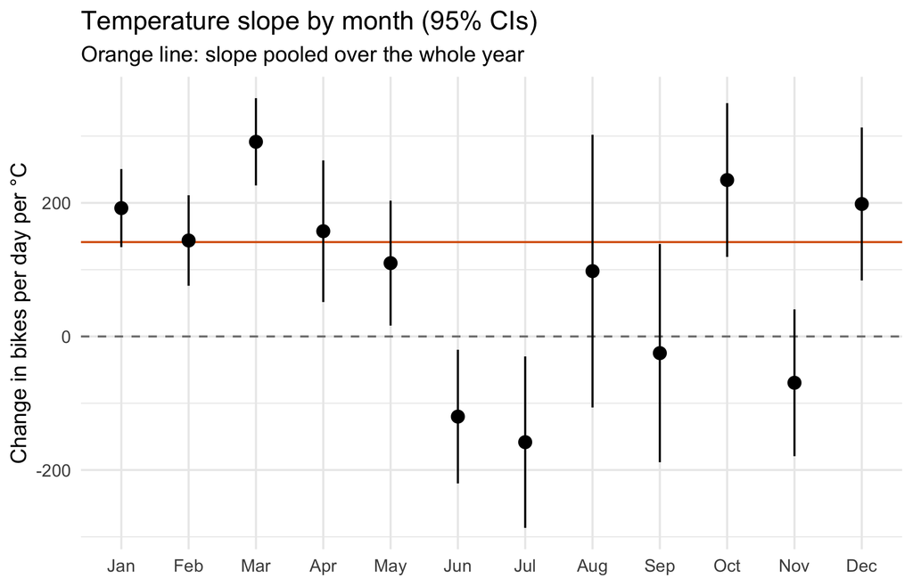

```r
ggplot(month_slopes, aes(month, estimate)) +
  geom_hline(yintercept = 0, linetype = "dashed", colour = "grey50") +
  geom_hline(yintercept = b_temp_uni, colour = "#D95F0E") +
  geom_pointrange(aes(ymin = conf.low, ymax = conf.high)) +
  labs(x = NULL, y = "Change in bikes per day per °C",
       title = "Temperature slope by month (95% CIs)",
       subtitle = "Orange line: slope pooled over the whole year")
```

A single model with a temperature × month interaction tests whether the slopes differ:

```r
m_add <- lm(cnt ~ temp_c + month, data = bikes)
m_int <- lm(cnt ~ temp_c * month, data = bikes)

anova(m_add, m_int) |>
  tidy() |>
  kable(digits = 4, caption = "Table 7. Does the temperature slope differ by month?")
```

Table 7. Does the temperature slope differ by month?

| term | df.residual | rss | df | sumsq | statistic | p.value |
| --- | --- | --- | --- | --- | --- | --- |
| cnt ~ temp_c + month | 718 | 1515141973 | NA | NA | NA | NA |
| cnt ~ temp_c * month | 707 | 1359055806 | 11 | 156086167 | 7.3817 | 0 |

One caveat: the data cover 2011 and 2012, and rentals grew strongly in the second year (see `yr`). Within-month slopes therefore also absorb some year-to-year growth, which is a reason not to over-interpret small differences between months.